# A *Light* Recipe to Train Robust Vision Transformers

Presentation by: **Pranjal Gulati**

### Transformers for robustness

- *non-adversarially* trained transformers show better robustness than CNNs to non-adversarial examples (common corruptions, semantic shifts, ood samples) ([Paul et. al.](https://arxiv.org/abs/2105.07581))
- BUT, recent study shows transformers are no more adversarially robust than CNNs ([Bai et. al.](https://arxiv.org/abs/2111.05464))
- current paper claims it is just a result of sub-par training recipes

### Searching for a better training recipe

- data augmentation policy
- warmup for perturbation budget $\epsilon$
- weight decay

### Training parameters

- *training time*: XCiT-S12, pod with 64TPUv4 cores, 256 batch, 110 epochs => 19h 30min (need more analysis!!)
- *training attack*: FGSM for AT, epsilon 4/255 (2 step attack used for some variants)

### Canonical training

- to achieve good performance with ViTs without pretraining, we apply strong data augmentations
- *mixup, cutmix, random erasing* helps compensate for the vision priors missing in transformers
- **28.7%** AutoAttack accuracy (35.51% with ResNet-50 ([Bai et. al.](https://arxiv.org/abs/2111.05464)), using a setup that does not differ from the standard ResNet setup)

### Weak augmentations

- robust accuracy improves by **3.84%** when using basic augmentations like *flips, resize, color jitter* instead of heavy ones listed before
- AT already introduces regularization (within the inner maximization), strong augmentations make the optimization harder

```python
torchvision.transforms.ColorJitter(brightness=0.4)
torchvision.transforms.RandomHorizontalFlip(p=0.5)
torchvision.transforms.RandomResizedCrop(size=224,
                                         scale=(0.08, 1.0),
                                         ratio=(0.75, 1.33))
```

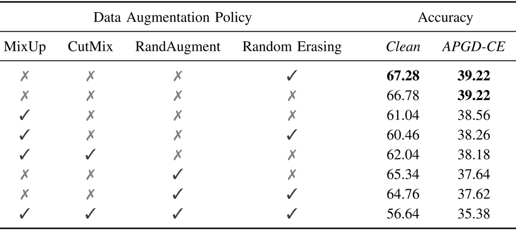

### More optimization setup

- **epsilon warmup**: 20 epoch linear warmup for adversarial perturbation budget
  - [Bai et. al.](https://arxiv.org/abs/2111.05464) failed to adversarially trained DeiT
  - authors trained an XCiT-N12 with successful training, but training struggled for the first few epochs
- **weight decay**: used a higher decay (10x) of **0.5** than what was used in XCiT training

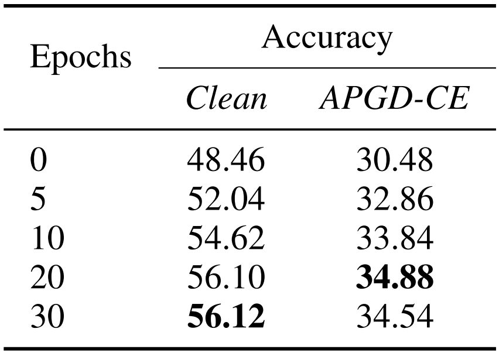

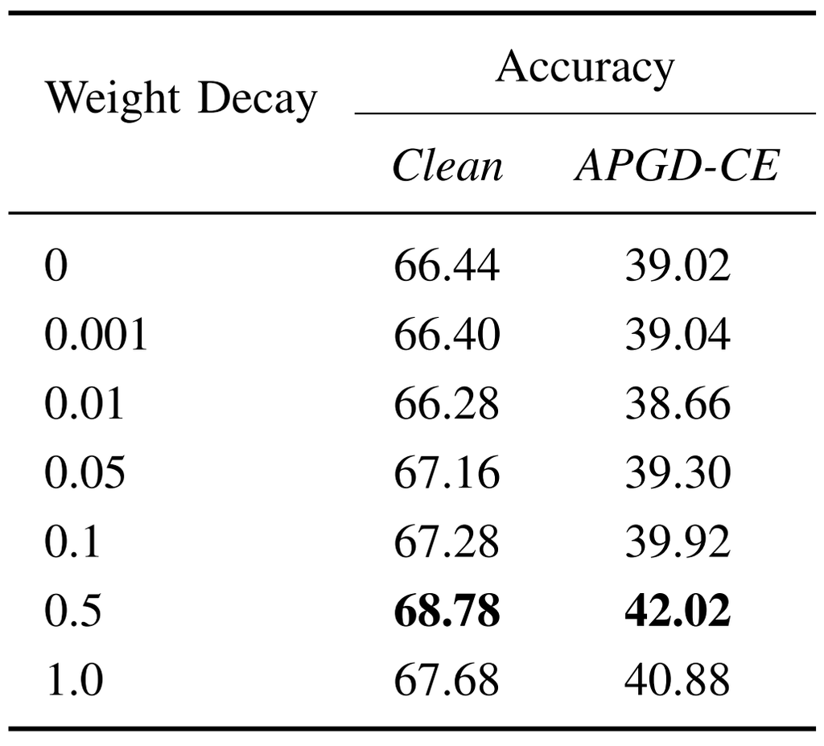

### Comparision of training recipes

| Canonical | Proposed |
| --- | --- |
| no warmup | 20 epoch linear warmup |
| strong data augs (mixup, cutmix, random erasing) | weak data augs (flips, resize, color jitter) |
| decay 0.05 | decay 0.5 |

### Step by step improvements

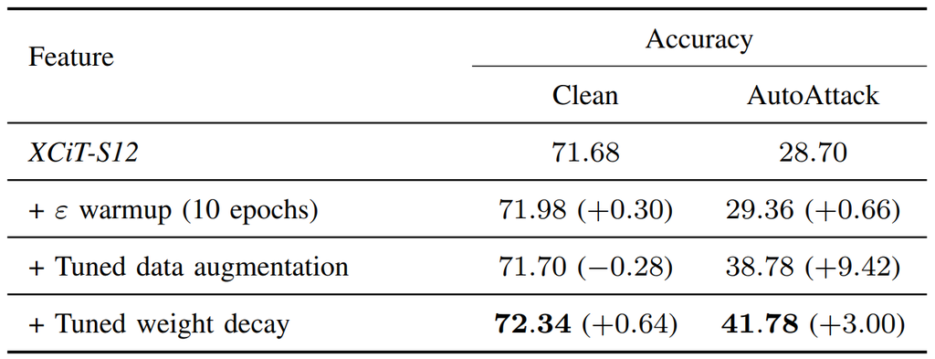

### Cross architecture generalization

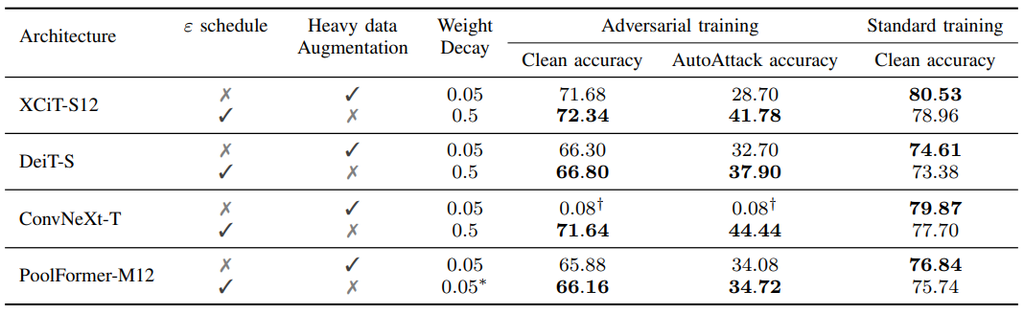

### Current state of RobustBench leaderboard

**Setup: ImageNet, l-infinity = 4/255, untargeted attack**

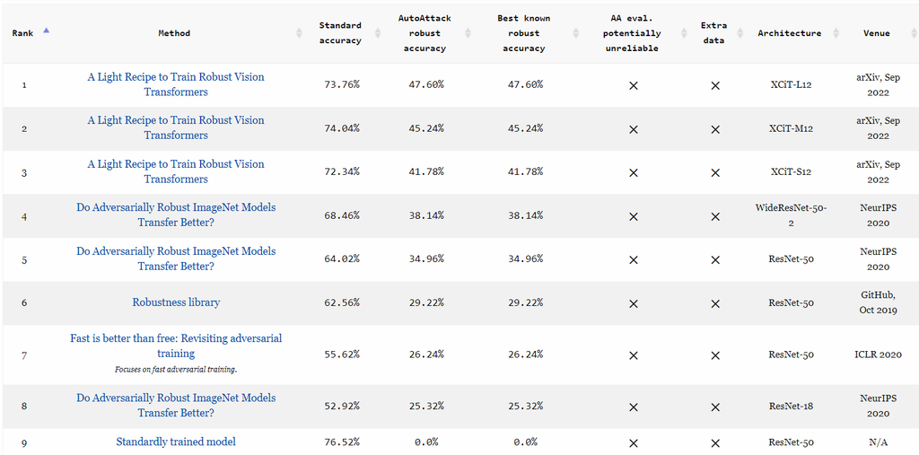

### Comparisions with DeACL recipe

- DeACL uses a much *lower weight decay* (**5e-4**)
  - but that is required since higher wd for ResNet-18 makes training unstable
  - current paper authors also use a wd of 0.05 (instead of 0.5) for PoolFormer-M12, which has lesser parameters than ResNet-50
  - but wd in AT stage is still 10x that used in SSL stage for DeACL
- DeACL also uses *weak data augmentations* for AT stage
  - since DeACL uses CIFAR-10, they use even weaker augmentations (color jitter is considered strong here)
- DeACL does not mention *epsilon warmup*
  - Priyam has already conducted successful experiments with varying epsilon

### Understanding success of VITs in AT

- *attack effectiveness*: the key question is not whether it is easy to solve inner max (attack) but whether its easy under few steps
  - choice of network architecture impacts optimization sucess
  - single-step attack is more effective against their trained XCiT than a ResNet-50 network
- the way we perform the (outer) min optimization of adversarial training influences the ease of (inner) max optimization,

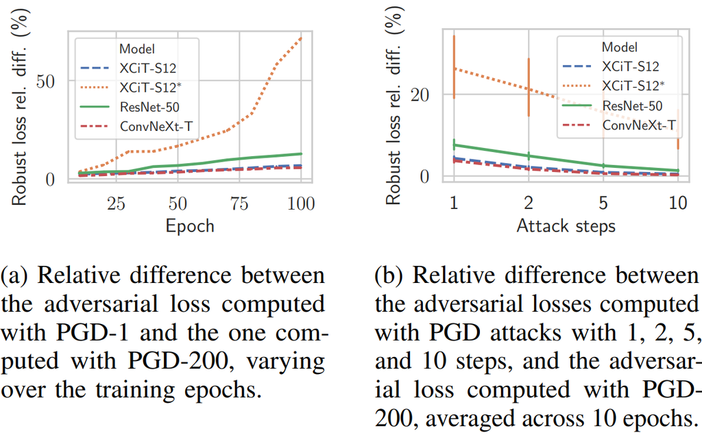